# Wastewater Surveillance as a Multivariate Change-Point Problem

```r
library(tidyverse) # for data handling
library(ggplot2) # for plotting
library(knitr) # for rendering vignette + tables
library(canadianmaps) # for mapping canadian cities
library(sf) # for spatial vector data (mapping)
library(maps) # for database of world cities
library(naniar) # for missing data visualization

#multichangepoints from Github
devtools::load_all("~/Dropbox/CANSSI/multi-change-points/")
library(multichangepoints)
set.seed(20260305)
```

## Introduction

Wastewater-based epidemiology (WBE) monitors the concentration of pathogen genetic material — such as SARS-CoV-2 RNA — in municipal wastewater. Because viral shedding into sewage can precede clinical case reporting by days to weeks [Peng et al (2025)](https://www.sciencedirect.com/science/article/pii/S1755436525000283), surveillance networks that continuously sample and sequence wastewater at multiple sites can provide early-warning signals of emerging or resurging outbreaks, and identify which sites are effected in order to triage resources.

From a statistical perspective, a national WBE network yields a **multivariate data stream**: at each time point $t$ (here, each epidemiological week), we observe a measurement $X_{tk}$ at each of $K$ monitoring sites. The surveillance task has two components:

1. **Change-point detection** — raise an alarm as soon as the data depart from a baseline regime, controlling a type-I error criterion such as the probability of false alarm (PFA) or the average run length under the null (ARL).
2. **Stream identification** — after (or concurrent with) an alarm, determine *which* sites $k$ are driving the change, so that public-health resources can be directed appropriately.

The `multichangepoints` package is designed for this setting. A univariate test supermartingale (TSM) is built for each site, marginal increment sequences are combined across sites (via `ProductCombiner`, `AverageCombiner`, or `UniversalPortfolioCombiner`), and a single `ShiryaevRobertsDetector` monitors the combined evidence sequentially — stopping as soon as the evidence crosses a threshold that guarantees the desired error control. Localization is accomodated by the `LocalizedDetector`, which uses the same TSMs but allocates a spending allowance across sites in a way that prioritizes those that are “near” alarmed sites.

## Data

The dataset `wastewater_aggregate.csv` is published by the Public Health Agency of Canada (PHAC), aggregating weekly wastewater measurements from monitoring sites across Canada.  
Each row contains one observation indexed by `site` by `week` by `pathogen`. Key columns:

[output not shown]

```r
#NB: data dictionary says empty sites indicate aggregates, but there are no empty sites
ww <- read_csv(
  here::here("Data", "wastewater_aggregate.csv"),
  show_col_types = FALSE
) %>%
  mutate(weekstart = as.Date(weekstart))
```

```r
head(ww)
```

```
#> # A tibble: 6 × 14
#>   Location site     city   province country EpiYear EpiWeek weekstart  measureid
#>   <chr>    <chr>    <chr>  <chr>    <chr>     <dbl>   <dbl> <date>     <chr>
#> 1 Alberton Alberton Alber… Prince … Canada     2022      44 2022-10-30 covN2
#> 2 Alberton Alberton Alber… Prince … Canada     2022      45 2022-11-06 covN2
#> 3 Alberton Alberton Alber… Prince … Canada     2022      46 2022-11-13 covN2
#> 4 Alberton Alberton Alber… Prince … Canada     2022      47 2022-11-20 covN2
#> 5 Alberton Alberton Alber… Prince … Canada     2022      48 2022-11-27 covN2
#> 6 Alberton Alberton Alber… Prince … Canada     2022      49 2022-12-04 covN2
#> # ℹ 5 more variables: w_avg <dbl>, min <dbl>, max <dbl>,
#> #   populationcoverage <dbl>, pruid <dbl>
```

## COVID-19 (covN2)

We filter to the SARS-CoV-2 N2 gene target and remove the national-aggregate rows (blank site name), retaining only site-level observations.

```r
cov <- ww %>%
  select(Location, site, province, country, weekstart, measureid, w_avg) %>%
  filter(measureid %in% c("covN2", "rsv"), site != "") %>%
  mutate(province = if_else(province == "", NA_character_, province)) %>%
  pivot_wider(values_from = "w_avg", names_from = "measureid") %>%
  mutate(covid_rsv_ratio = covN2/rsv)

cat(
  "Sites:", n_distinct(cov$site), "\n",
  "Provinces:", n_distinct(cov$province, na.rm = TRUE), "\n",
  "Weeks:", n_distinct(cov$weekstart), "\n",
  "Rows:", nrow(cov), "\n"
)
```

```
#> Sites: 75
#>  Provinces: 11
#>  Weeks: 280
#>  Rows: 11272
```

### Sampling locations and number of observations

Sites vary in their number of observations primarily because monitoring started at different times at different sites, but also because some weeks are missing measurements.

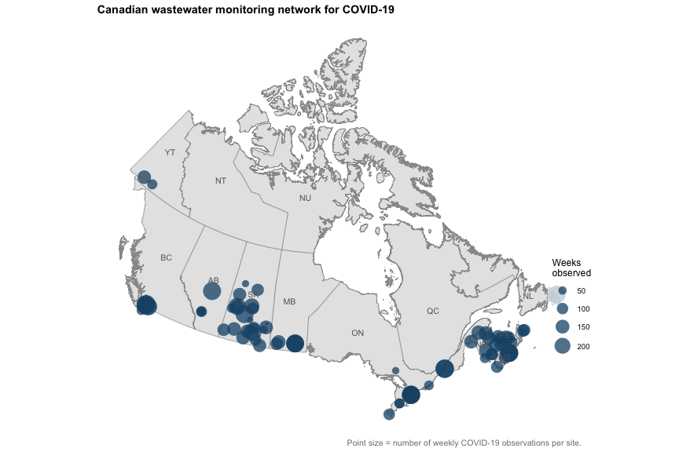

Canadian wastewater monitoring sites. Point size reflects the number of observations of COVID-19 viral loads; province abbreviations from canadianmaps.

```r
# ---- observation counts per site -------------------------------------------
site_counts <- ww %>%
  filter(site != "", measureid %in% c("covN2")) %>%
  group_by(site, city, province) %>%
  summarize(count = n()) %>%
  mutate(city_clean = trimws(city))

# ---- geocode: auto-match city names from maps::world.cities ----------------
ca_cities <- world.cities[world.cities$country.etc == "Canada", ]

# joins cities by name and take largest if there are any repeats
site_geo <- site_counts %>%
  left_join(
    ca_cities %>% select(name, lat, long, pop),
    by = c("city_clean" = "name"),
    relationship = "many-to-many"
  ) %>%
  group_by(site) %>%
  slice_max(pop, n = 1, with_ties = FALSE) %>%
  ungroup()

# ---- manual coordinates for the 18 unmatched sites -------------------------
manual_coords <- tribble(
  ~site,                                        ~lat,    ~long,
  "Battery Point",                              46.14,  -60.19,
  "Battleford",                                 52.73, -108.30,
  "Birch Hills",                                52.98, -105.44,
  "City of Charlottetown and Town of Stratford",46.24,  -63.13,
  "Dominion-Bridgeport",                        46.13,  -60.00,
  "Miramichi",                                  47.02,  -65.50,
  "Pasqua",                                     50.58, -103.98,
  "Peel G.E. Booth",                            43.73,  -79.72,
  "Southey",                                    50.95, -104.49,
  "St. John's",                                 47.56,  -52.71,
  "St. Stephen",                                45.20,  -67.28,
  "Trenton",                                    45.61,  -62.63,
  "Vancouver Annacis Island",                   49.17, -122.92,
  "Vancouver Iona Island",                      49.22, -123.21,
  "Vancouver Lions Gate",                       49.35, -123.13,
  "Vancouver Lulu Island",                      49.14, -123.19,
  "Vancouver Northwest Langley",                49.17, -122.60,
  "\u00cele-\u00e0-la-Crosse",                  55.45, -107.89
)

site_geo <- site_geo %>%
  rows_update(manual_coords, by = "site", unmatched = "ignore") %>%
  filter(!is.na(lat))

# ---- project points into the canadianmaps Lambert CRS ----------------------
lcc_crs <- "+proj=lcc +lat_1=49 +lat_2=77 +lon_0=-91.52 +x_0=0 +y_0=0 +datum=NAD83 +units=m +no_defs"

sites_sf <- site_geo %>%
  st_as_sf(coords = c("long", "lat"), crs = 4326) %>%
  st_transform(crs = lcc_crs)

# ---- map -------------------------------------------------------------------
ggplot() +
  geom_prov(fill = "gray93", colour = "gray60", size = 0.25) +
  geom_sf(
    data   = sites_sf,
    aes(size = count),
    colour = "#1A5276",
    alpha  = 0.75,
    shape  = 16
  ) +
  text_prov(colour = "gray40", size = 2.8) +
  scale_size_area(
    name     = "Weeks\nobserved",
    max_size = 8,
    breaks   = c(50, 100, 150, 200)
  ) +
  crs_coord() +
  labs(
    title   = "Canadian wastewater monitoring network for COVID-19",
    caption = "Point size = number of weekly COVID-19 observations per site."
  ) +
  theme_map() +
  theme(
    legend.position  = c(0.93, 0.18),
    legend.background = element_rect(fill = alpha("white", 0.7), colour = NA),
    legend.title     = element_text(size = 9),
    plot.title       = element_text(face = "bold", margin = margin(b = 4)),
    plot.caption     = element_text(colour = "gray50", size = 8,
                                    margin = margin(t = 4))
  )
```

### Trend overview — all sites

The plot below shows weekly COVID signal (`covN2`) at every monitoring site as a thin semi-transparent line, with the national average overlaid in bold. Vertical dashed lines mark approximate Omicron wave peaks for reference.

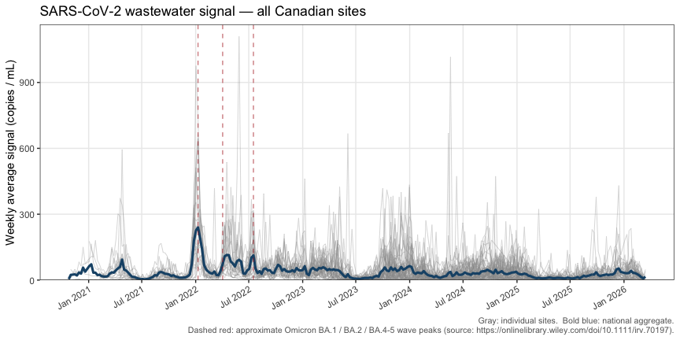

Weekly SARS-CoV-2 wastewater signal at all Canadian monitoring sites (COVID). Each gray line is one site; the national aggregate (bold blue) reflects the country-wide trajectory.

```r
national <- ww %>%
  filter(measureid == "covN2") %>%
  group_by(weekstart) %>%
  summarize(covN2 = mean(w_avg)) %>%
  mutate(province = "National")

ggplot() +
  # Individual sites
  geom_line(
    data  = cov,
    aes(x = weekstart, y = covN2, group = site),
    colour = "gray60", alpha = 0.35, linewidth = 0.35
  ) +
  # National aggregate
  geom_line(
    data      = national,
    aes(x = weekstart, y = covN2),
    colour    = "#1A5276",
    linewidth = 1.1
  ) +
  # Approximate Omicron wave peaks (BA.1, BA.2, BA.4/5)
  geom_vline(
    xintercept = as.Date(c("2022-01-09", "2022-04-03", "2022-07-17")),
    linetype   = "dashed",
    colour     = "firebrick",
    alpha      = 0.55
  ) +
  scale_x_date(date_breaks = "6 months", date_labels = "%b %Y") +
  scale_y_continuous(
    labels = scales::label_comma(),
    expand = expansion(mult = c(0, 0.05))
  ) +
  labs(
    x       = NULL,
    y       = "Weekly average signal (copies / mL)",
    title   = "SARS-CoV-2 wastewater signal — all Canadian sites",
    caption = "Gray: individual sites.  Bold blue: national aggregate.
Dashed red: approximate Omicron BA.1 / BA.2 / BA.4-5 wave peaks (source: https://onlinelibrary.wiley.com/doi/10.1111/irv.70197)."
  ) +
  theme_bw(base_size = 11) +
  theme(
    axis.text.x     = element_text(angle = 30, hjust = 1),
    plot.caption    = element_text(colour = "gray40", size = 8),
    panel.grid.minor = element_blank()
  )
```

### Trends by province

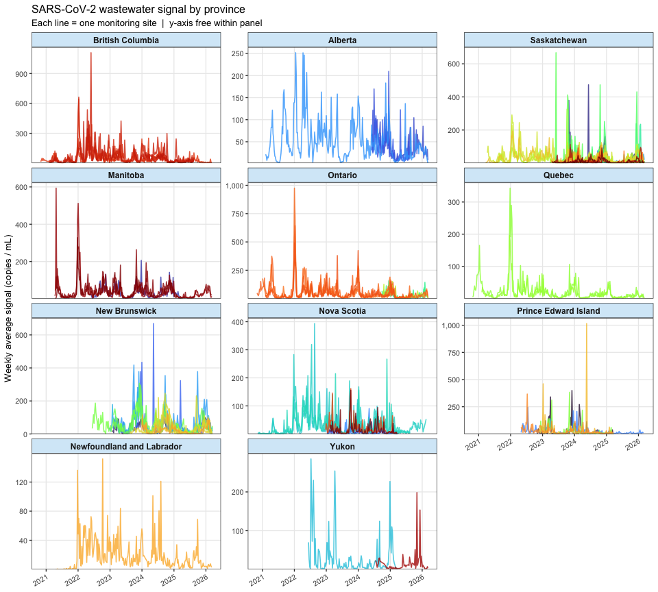

SARS-CoV-2 wastewater signal by province. Each line is one monitoring site; colour distinguishes sites within a province.

```r
# Provinces with at least some data — ordered W → E then territories
province_order <- c(
  "British Columbia", "Alberta", "Saskatchewan", "Manitoba",
  "Ontario", "Quebec",
  "New Brunswick", "Nova Scotia", "Prince Edward Island",
  "Newfoundland and Labrador",
  "Yukon"
)

cov_prov <- cov %>%
  filter(!is.na(province)) %>%
  mutate(province = factor(province, levels = province_order))

ggplot(cov_prov, aes(x = weekstart, y = covN2,
                     colour = site, group = site)) +
  geom_line(linewidth = 0.55, alpha = 0.8) +
  facet_wrap(~ province, ncol = 3, scales = "free_y") +
  scale_x_date(date_breaks = "1 year", date_labels = "%Y") +
  scale_y_continuous(
    labels = scales::label_comma(),
    expand = expansion(mult = c(0, 0.05))
  ) +
  scale_colour_viridis_d(option = "turbo", guide = "none") +
  labs(
    x     = NULL,
    y     = "Weekly average signal (copies / mL)",
    title = "SARS-CoV-2 wastewater signal by province",
    subtitle = "Each line = one monitoring site  |  y-axis free within panel"
  ) +
  theme_bw(base_size = 10) +
  theme(
    axis.text.x      = element_text(angle = 30, hjust = 1, size = 8),
    strip.background = element_rect(fill = "#D6EAF8"),
    strip.text       = element_text(face = "bold", size = 9),
    panel.grid.minor = element_blank()
  )
```

The wave structure is broadly synchronous across provinces — consistent with a national-level change in pathogen prevalence — but the magnitude and timing of individual site peaks vary, reflecting local population sizes, sampling frequency, and catchment characteristics. This heterogeneity motivates a **multi-stream approach**: rather than pooling sites into a single signal, the `multichangepoints` framework tests each site sequentially and combines the evidence in a principled way, allowing the detector to remain powerful even when only a subset of sites shows an elevated signal.

### Missing Data

Some sites are missing weeks, wherein COVID-19 measurements were not taken.

```r
missing_by_site <- cov %>%
  group_by(site) %>%
  summarize(
    first_week = min(weekstart),
    last_week  = max(weekstart),
    observed   = list(sort(unique(weekstart))),
    .groups    = "drop"
  ) %>%
  rowwise() %>%
  mutate(
    expected           = list(seq(first_week, last_week, by = "7 days")),
    n_expected_observed = length(expected),
    n_missing          = sum(!expected %in% observed),
    pct_missing        = round(100 * n_missing / n_expected_observed, 1)
  ) %>%
  ungroup() %>%
  select(site, n_expected_observed, n_missing, pct_missing) %>%
  arrange(desc(n_expected_observed), pct_missing)

# these are the most 'complete' sites, with the longest observations and the fewest missing
head(missing_by_site, 10)
```

```
#> # A tibble: 10 × 4
#>    site                     n_expected_observed n_missing pct_missing
#>    <chr>                                  <int>     <int>       <dbl>
#>  1 Montreal North                           281         4         1.4
#>  2 Vancouver Annacis Island                 280         2         0.7
#>  3 Toronto Humber                           280         6         2.1
#>  4 Halifax Halifax                          275         5         1.8
#>  5 Toronto Ashbridges Bay                   271         5         1.8
#>  6 Vancouver Iona Island                    266         1         0.4
#>  7 Montreal South                           266         3         1.1
#>  8 Edmonton Goldbar                         266         6         2.3
#>  9 Saskatoon                                260         2         0.8
#> 10 Winnipeg North End                       257         1         0.4
```

```r
# For each site (row), linearly interpolate only between the first and last
# observed (non-NA) value. NAs outside that window remain NA (site offline).
impute_row <- function(row) {
  obs <- which(!is.na(row))
  if (length(obs) < 2L) return(row)
  first <- obs[1L]; last <- obs[length(obs)]
  row[first:last] <- approx(obs, row[obs], xout = first:last)$y
  row
}
```

# Change-point detection for WBE

Defining a meaningful state of control is the central challenge of WBE. These data streams are subject to well-documented sources of noise and systematic uncertainty [Joung et al (2023)](https://pmc.ncbi.nlm.nih.gov/articles/PMC10890812/pdf/CCDR-49-166.pdf):

- **Target quantity**: The true target quantity of interest is the average viral load in a particular population week over week. This quantity varies naturally over time when the virus is in an endemic state. While this variation is not genuinely random, it can be modeled as such. For instance, we might assume it maintains some low-level average with as-if-Gaussian fluctuations from week to week, in which case the sequence is *stationary* in the endemic phase.
- **Sampling**: The methods of sample collection, shipping, and storage (compositing vs grab sampling, location, timing, shipping temperature, distance to lab, missing data), which may vary across sites and time. The sites that were selected for our purposes primarily used composite sampling.
- **Analysis**: Laboratory analysis variability (de-gritting subsampling, homogenization, instrument error, human error).
- **Infrastructure**: The location and engineering of sewage systems and wastewater treatment plants (catchment area size and population, combined or separate (‘sanitary’) collection of runoff and wastewater).
- **Weather**: Weather conditions (rainwater or snowmelt contributing to influent, temperature, pH), which vary across sites and seasons, with some degree of stochasticity.

In the literature, these uncertainties are dealt with under the rubric of *normalization*, which is an active area of research. In some sense, defining a proper state of control from which deviations are meaningful is the whole challenge of WBE. It may be easier to define the state of control for certain sites, like those with sanitary sewage systems that are less influenced by major weather events.

# Detection pipeline: graph-aware localized alarm on raw viral load

## Site selection

We redefine `selected_sites` with explicit inclusion criteria: enrolled by 2023-01-01, observed through 2026-01-01, and ≥ 80% complete data for both covN2 and RSV within that window.

```r
library(mgcv)

window_start <- as.Date("2023-01-01")
train_end    <- as.Date("2024-01-01")   # training = 2023 only; monitor 2024-2025
window_end   <- as.Date("2026-01-01")
spine_pipe   <- seq(window_start, window_end, by = "7 days")
n_expected   <- length(spine_pipe)

# Enrollment window from full raw data (covN2 used as the enrollment marker)
site_enrollment <- ww %>%
  filter(measureid == "covN2", site != "") %>%
  group_by(site) %>%
  summarize(first_obs = min(weekstart), last_obs = max(weekstart), .groups = "drop")

# Completeness for both covN2 and RSV within the evaluation window
site_completeness <- ww %>%
  filter(measureid %in% c("covN2", "rsv"), site != "",
         weekstart >= window_start, weekstart <= window_end) %>%
  select(site, weekstart, measureid, w_avg) %>%
  pivot_wider(names_from = measureid, values_from = w_avg) %>%
  group_by(site) %>%
  summarize(
    n_covN2   = sum(!is.na(covN2)),
    n_rsv     = sum(!is.na(rsv)),
    pct_covN2 = round(n_covN2 / n_expected, 3),
    pct_rsv   = round(n_rsv   / n_expected, 3),
    .groups   = "drop"
  ) %>%
  left_join(site_enrollment, by = "site") %>%
  mutate(
    enrolled_by_start = first_obs <= window_start,
    through_end       = last_obs  >= window_end,
    meets_criteria    = enrolled_by_start & through_end &
                        pct_covN2 >= 0.80 & pct_rsv >= 0.80
  )

# Report sites that fail
cat("=== Sites failing inclusion criteria ===\n")
```

```
#> === Sites failing inclusion criteria ===
```

```r
site_completeness %>%
  filter(!meets_criteria) %>%
  arrange(pct_rsv) %>%
  select(site, first_obs, last_obs, pct_covN2, pct_rsv,
         enrolled_by_start, through_end) %>%
  knitr::kable()
```

| site | first_obs | last_obs | pct_covN2 | pct_rsv | enrolled_by_start | through_end |
| --- | --- | --- | --- | --- | --- | --- |
| Assiniboia | 2023-05-28 | 2026-03-08 | 0.860 | 0.000 | FALSE | TRUE |
| Bathurst | 2023-01-29 | 2026-03-15 | 0.949 | 0.000 | FALSE | TRUE |
| Battleford | 2023-05-21 | 2026-03-08 | 0.847 | 0.000 | FALSE | TRUE |
| Birch Hills | 2023-05-28 | 2026-03-08 | 0.662 | 0.000 | FALSE | TRUE |
| Campbellton | 2023-02-05 | 2026-03-15 | 0.955 | 0.000 | FALSE | TRUE |
| Canora | 2023-05-28 | 2023-06-25 | 0.032 | 0.000 | FALSE | FALSE |
| Edmundston | 2023-03-19 | 2026-03-15 | 0.854 | 0.000 | FALSE | TRUE |
| Estevan | 2023-07-23 | 2026-03-08 | 0.803 | 0.000 | FALSE | TRUE |
| Fredericton | 2022-12-18 | 2026-03-08 | 0.866 | 0.000 | TRUE | TRUE |
| La Ronge | 2023-06-04 | 2026-03-08 | 0.675 | 0.000 | FALSE | TRUE |
| Lumsden | 2023-06-25 | 2024-09-08 | 0.401 | 0.000 | FALSE | FALSE |
| Maple Creek | 2023-08-20 | 2026-03-08 | 0.713 | 0.000 | FALSE | TRUE |
| Meadow Lake | 2023-06-11 | 2026-02-08 | 0.828 | 0.000 | FALSE | TRUE |
| Melville | 2023-05-14 | 2024-05-12 | 0.293 | 0.000 | FALSE | FALSE |
| Miramichi | 2023-02-12 | 2026-03-15 | 0.879 | 0.000 | FALSE | TRUE |
| Moncton | 2022-06-12 | 2026-03-15 | 0.962 | 0.000 | TRUE | TRUE |
| Moose Jaw | 2023-04-09 | 2026-03-08 | 0.834 | 0.000 | FALSE | TRUE |
| North Battleford | 2021-08-01 | 2026-03-08 | 0.968 | 0.000 | TRUE | TRUE |
| Pasqua | 2023-05-07 | 2023-09-24 | 0.115 | 0.000 | FALSE | FALSE |
| Prince Albert | 2021-06-20 | 2026-03-08 | 0.637 | 0.000 | TRUE | TRUE |
| Sackville | 2024-02-11 | 2026-03-15 | 0.541 | 0.000 | FALSE | TRUE |
| Saint John - Eastern Site | 2023-08-13 | 2026-03-15 | 0.643 | 0.000 | FALSE | TRUE |
| Saint John - Lancaster Site | 2024-01-21 | 2026-03-15 | 0.624 | 0.000 | FALSE | TRUE |
| Saskatoon | 2021-03-21 | 2026-03-08 | 0.987 | 0.000 | TRUE | TRUE |
| Southey | 2023-05-28 | 2026-01-11 | 0.631 | 0.000 | FALSE | TRUE |
| St. Stephen | 2023-12-31 | 2026-02-22 | 0.420 | 0.000 | FALSE | TRUE |
| Swift Current | 2023-04-09 | 2026-03-08 | 0.866 | 0.000 | FALSE | TRUE |
| Unity | 2023-05-28 | 2024-10-27 | 0.408 | 0.000 | FALSE | FALSE |
| Watrous | 2023-05-28 | 2024-11-10 | 0.185 | 0.000 | FALSE | FALSE |
| Weyburn | 2023-05-28 | 2026-03-01 | 0.624 | 0.000 | FALSE | TRUE |
| Yorkton | 2023-04-23 | 2026-03-08 | 0.885 | 0.000 | FALSE | TRUE |
| Île-à-la-Crosse | 2023-07-23 | 2024-03-24 | 0.229 | 0.000 | FALSE | FALSE |
| Sudbury | 2024-12-15 | 2025-08-31 | 0.242 | 0.242 | FALSE | FALSE |
| Kingston Cataraqui Bay | 2024-10-13 | 2026-03-08 | 0.382 | 0.382 | FALSE | TRUE |
| Victoria | 2024-05-26 | 2025-08-17 | 0.395 | 0.395 | FALSE | FALSE |
| Calgary Fish Creek | 2024-06-02 | 2025-08-17 | 0.408 | 0.408 | FALSE | FALSE |
| Calgary Pine Creek | 2024-06-02 | 2025-08-17 | 0.408 | 0.408 | FALSE | FALSE |
| London Greenway North | 2024-09-29 | 2026-03-08 | 0.414 | 0.414 | FALSE | TRUE |
| London Greenway South | 2024-09-29 | 2026-03-08 | 0.414 | 0.414 | FALSE | TRUE |
| Peel G.E. Booth | 2024-09-22 | 2026-03-15 | 0.414 | 0.414 | FALSE | TRUE |
| Whitehorse - Marwell | 2024-07-14 | 2026-03-08 | 0.427 | 0.427 | FALSE | TRUE |
| Calgary Bonnybrook | 2024-06-02 | 2026-03-08 | 0.522 | 0.522 | FALSE | TRUE |
| Central Colchester | 2023-03-26 | 2025-03-23 | 0.656 | 0.656 | FALSE | FALSE |
| Yarmouth | 2023-02-12 | 2025-03-23 | 0.688 | 0.688 | FALSE | FALSE |
| Alberton | 2022-10-30 | 2025-03-23 | 0.713 | 0.713 | TRUE | FALSE |
| Trenton | 2022-12-25 | 2025-03-23 | 0.732 | 0.732 | TRUE | FALSE |
| Bridgewater | 2023-01-01 | 2025-03-30 | 0.739 | 0.739 | TRUE | FALSE |
| Dominion-Bridgeport | 2023-01-15 | 2025-03-30 | 0.739 | 0.739 | FALSE | FALSE |
| Souris | 2022-11-20 | 2025-03-23 | 0.739 | 0.739 | TRUE | FALSE |
| Battery Point | 2023-01-08 | 2025-03-30 | 0.745 | 0.745 | FALSE | FALSE |
| Brandon | 2022-05-22 | 2025-03-23 | 0.745 | 0.745 | TRUE | FALSE |
| Haines Junction | 2022-06-12 | 2025-03-23 | 0.745 | 0.745 | TRUE | FALSE |
| Montague | 2022-11-20 | 2025-03-23 | 0.745 | 0.745 | TRUE | FALSE |
| Summerside | 2022-05-01 | 2025-03-23 | 0.745 | 0.745 | TRUE | FALSE |
| Halifax Dartmouth | 2020-11-08 | 2025-08-17 | 0.854 | 0.854 | TRUE | FALSE |
| Halifax Millcove | 2020-11-15 | 2025-08-17 | 0.879 | 0.879 | TRUE | FALSE |
| Toronto North Toronto | 2021-02-07 | 2025-09-07 | 0.879 | 0.879 | TRUE | FALSE |
| Vancouver Lions Gate | 2021-02-07 | 2025-08-17 | 0.879 | 0.879 | TRUE | FALSE |
| Vancouver Lulu Island | 2021-02-07 | 2025-08-17 | 0.879 | 0.879 | TRUE | FALSE |
| Vancouver Northwest Langley | 2021-02-07 | 2025-08-17 | 0.879 | 0.879 | TRUE | FALSE |
| Toronto Highland Creek | 2021-02-07 | 2025-09-07 | 0.892 | 0.892 | TRUE | FALSE |
| Winnipeg West End | 2021-04-11 | 2025-08-31 | 0.892 | 0.892 | TRUE | FALSE |

```r
# Redefine selected_sites
selected_sites <- site_completeness %>%
  filter(meets_criteria) %>%
  arrange(site) %>%
  pull(site)

cat("\nSelected sites (n =", length(selected_sites), "):\n")
```

```
#>
#> Selected sites (n = 13 ):
```

```r
cat(paste(selected_sites, collapse = "\n"), "\n")
```

```
#> City of Charlottetown and Town of Stratford
#> Edmonton Goldbar
#> Halifax Halifax
#> Montreal North
#> Montreal South
#> Regina
#> St. John's
#> Toronto Ashbridges Bay
#> Toronto Humber
#> Vancouver Annacis Island
#> Vancouver Iona Island
#> Winnipeg North End
#> Winnipeg South End
```

## Data preparation: log1p transform, per-site 2023 normalization

```r
K_sites <- length(selected_sites)

pipe_long <- ww %>%
  filter(measureid == "covN2", site %in% selected_sites,
         weekstart >= window_start, weekstart <= window_end) %>%
  select(site, weekstart, covN2 = w_avg) %>%
  # Fill the full weekly spine and interpolate gaps within each site's observed window
  complete(site, weekstart = spine_pipe) %>%
  arrange(site, weekstart) %>%
  group_by(site) %>%
  mutate(covN2 = impute_row(covN2),
         log_covN2 = log1p(covN2)) %>%
  ungroup()

# Per-site normalizer: average log1p(covN2) observed in the 2023 training year
mean2023_k <- pipe_long %>%
  filter(weekstart < train_end) %>%
  group_by(site) %>%
  summarize(mean2023 = mean(log_covN2, na.rm = TRUE), .groups = "drop")

pipe_long <- pipe_long %>%
  left_join(mean2023_k, by = "site") %>%
  mutate(norm = log_covN2 / mean2023)

cat("NAs remaining after imputation:", sum(is.na(pipe_long$norm)),
    "(leading/trailing offline periods)\n")
```

```
#> NAs remaining after imputation: 13 (leading/trailing offline periods)
```

```r
# Wide matrix: K_sites rows x n_weeks columns
norm_matrix <- pipe_long %>%
  select(site, weekstart, norm) %>%
  pivot_wider(names_from = weekstart, values_from = norm) %>%
  column_to_rownames("site") %>%
  as.matrix()
```

## Training-period thresholds and short-memory AGRAPA bets

Because every site is already normalized to its own 2023 average, $\eta_k = 1$ for every site $k$ by construction – a detection identifies where the (EWMA-smoothed) log1p signal’s local mean exceeds what was typical in 2023. The AGRAPA bet still uses the short-memory EWMA ($\rho = 0.7$, i.e. 70% weight on the most recent observation) from before. `mu_init` (the bet’s starting mean estimate, before any monitoring-period data has arrived) is, for the same reason, also exactly 1 for every site, so the bet starts right at the null boundary.

```r
train_idx <- which(spine_pipe <  train_end)
test_idx  <- which(spine_pipe >= train_end)

eta_k     <- setNames(rep(1, K_sites), rownames(norm_matrix))
mu_init_k <- setNames(rep(1, K_sites), rownames(norm_matrix))
```

### Transformed signal, 2023-2025

By construction every site’s 2023 (training, grey) trajectory averages exactly 1 (dotted line, $\eta_k$); the question the detector asks of 2024-2025 (blue) is whether the local mean climbs back up to that same historical average.

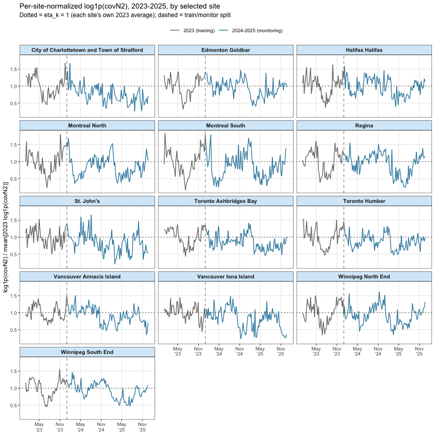

```r
pipe_long %>%
  mutate(period = if_else(weekstart < train_end, "2023 (training)", "2024-2025 (monitoring)")) %>%
  ggplot(aes(x = weekstart, y = norm, colour = period, group = site)) +
  geom_line(linewidth = 0.5, na.rm = TRUE) +
  geom_hline(yintercept = 1, linetype = "dotted", colour = "grey30", linewidth = 0.5) +
  geom_vline(xintercept = train_end, linetype = "dashed", colour = "grey50", linewidth = 0.4) +
  facet_wrap(~ site, ncol = 3) +
  scale_colour_manual(values = c("2023 (training)"        = "gray45",
                                 "2024-2025 (monitoring)" = "#2E86AB"),
                      name = NULL) +
  scale_x_date(date_breaks = "6 months", date_labels = "%b\n'%y") +
  labs(x = NULL, y = "log1p(covN2) / mean[2023 log1p(covN2)]",
       title = "Per-site-normalized log1p(covN2), 2023-2025, by selected site",
       subtitle = "Dotted = eta_k = 1 (each site's own 2023 average); dashed = train/monitor split") +
  theme_bw(base_size = 9) +
  theme(legend.position   = "top",
        strip.background  = element_rect(fill = "#D6EAF8"),
        strip.text        = element_text(face = "bold", size = 8),
        panel.grid.minor  = element_blank())
```

```r
test_mat   <- t(norm_matrix[, test_idx, drop = FALSE])   # N_test x K_sites
test_dates <- spine_pipe[test_idx]
N_test     <- nrow(test_mat)

inc_mat <- matrix(NA_real_, nrow = N_test, ncol = K_sites,
                  dimnames = list(NULL, rownames(norm_matrix)))
for (k in seq_len(K_sites)) {
  bm_k <- BoundedModel(eta = eta_k[k], bets = EWMABet(rho = 0.7, mu_init = mu_init_k[k]))
  inc_mat[, k] <- compute_increments(TSM(bm_k), test_mat[, k], log = TRUE)
}
```

## A proximity graph on the K = 13 sites

We build a `ProximityGraph` on the selected sites with great-circle distance (km) as the edge weight, geocoding each site the same way as the sampling-locations map above (`world.cities` join, with manual overrides for the metro-area facility names it can’t match). For now the graph is taken to be fully connected – every pair of sites gets an edge – since we have no stronger prior on the true transmission network between them; see Section 8 of the manuscript for discussion.

```r
site_city <- ww %>%
  filter(site %in% selected_sites) %>%
  distinct(site, city, province) %>%
  mutate(city_clean = trimws(city))

site_geo_k <- site_city %>%
  left_join(
    ca_cities %>% select(name, lat, long, pop),   # ca_cities: from the sampling-locations map above
    by = c("city_clean" = "name"),
    relationship = "many-to-many"
  ) %>%
  group_by(site) %>%
  slice_max(pop, n = 1, with_ties = FALSE) %>%
  ungroup() %>%
  rows_update(manual_coords, by = "site", unmatched = "ignore") %>%
  filter(!is.na(lat)) %>%
  arrange(match(site, selected_sites))

stopifnot(nrow(site_geo_k) == K_sites, all(site_geo_k$site == rownames(norm_matrix)))
```

```r
haversine_km <- function(lat1, lon1, lat2, lon2) {
  R <- 6371; to_rad <- pi / 180
  dlat <- (lat2 - lat1) * to_rad; dlon <- (lon2 - lon1) * to_rad
  a <- sin(dlat / 2)^2 + cos(lat1 * to_rad) * cos(lat2 * to_rad) * sin(dlon / 2)^2
  2 * R * asin(pmin(1, sqrt(a)))
}

# City-centroid geocoding puts same-city facility pairs (the two Toronto,
# Montreal, Winnipeg, and Vancouver-area sites) at (near-)identical
# coordinates; floor at a nominal 5 km since city-level geocoding can't
# resolve true intra-city facility separation, and a structural zero would
# read as "no edge" under ProximityGraph's convention.
MIN_DIST_KM <- 5
W_prox <- matrix(0, K_sites, K_sites)
for (i in seq_len(K_sites)) for (j in seq_len(K_sites)) {
  if (i != j) W_prox[i, j] <- max(MIN_DIST_KM,
    haversine_km(site_geo_k$lat[i], site_geo_k$long[i],
                site_geo_k$lat[j], site_geo_k$long[j]))
}
prox_graph <- ProximityGraph(W_prox, names = site_geo_k$site)

cat("Edge weight (km) summary:\n")
```

```
#> Edge weight (km) summary:
```

```r
print(summary(W_prox[upper.tri(W_prox)]))
```

```
#>    Min. 1st Qu.  Median    Mean 3rd Qu.    Max.
#>     5.0   973.1  1851.1  2089.5  3193.0  5014.2
```

## Choosing the kernel bandwidth

The proximity allowance (Section 5.3 of the manuscript) redirects budget toward not-yet-alarmed sites in proportion to $\kappa(d) = e^{-d/\xi}$, so $\xi$ should be small relative to the *typical* distance between sites – otherwise the kernel is nearly flat and the allowance barely differs from uniform – but large enough that a plausible “regional cluster” of nearby cities still gets a meaningful boost, not just exact same-city duplicates. The distances above are heavily right-skewed: same-metro pairs sit at the 5 km floor, the next-nearest real neighbors are a few hundred km apart, and the bulk of pairs are continental (1,000-5,000 km). A bandwidth of $\xi = 200$ km separates these regimes cleanly:

```r
xi <- 200
d_check <- c(same_metro = 5, near_neighbor = 200, regional = 500, continental = 2000)
cat("kernel weight at illustrative distances (xi =", xi, "km):\n")
```

```
#> kernel weight at illustrative distances (xi = 200 km):
```

```r
print(round(exp(-d_check / xi), 3))
```

```
#>    same_metro near_neighbor      regional   continental
#>         0.975         0.368         0.082         0.000
```

so a same-metro pair keeps almost its full weight, a site a couple hundred km away still gets roughly a third of that, and anything beyond about 1,000 km contributes almost nothing – i.e. the allowance reacts quickly to genuinely nearby cities without being diluted by the long tail of far-away sites. `xi` is easy to re-tune from the same distance summary above if a sharper or looser focus is preferred.

## Two spending allowances: uniform vs. graph-aware

We compare the uniform e-d-Bonferroni allowance to the graph-aware proximity allowance (exponential kernel, $\xi = 200$ km, focus parameter $\zeta = 0.9$) on the same increments, both controlling the same global ARL.

```r
alpha_global <- 1 / 52   # one false alarm every year, on average
log_thresh   <- log(1 / alpha_global)

ld_unif <- LocalizedDetector(K = K_sites, alpha = alpha_global, criterion = "ARL")
ld_prox <- LocalizedDetector(
  K = K_sites, alpha = alpha_global, criterion = "ARL",
  proximity_graph = prox_graph,
  kernel          = exponential_kernel(xi = xi),
  zeta            = 0.9
)

det_unif <- run_detector(ld_unif, evidence = inc_mat, log = TRUE)
det_prox <- run_detector(ld_prox, evidence = inc_mat, log = TRUE)

stop_to_date <- function(stops) {
  out <- rep("no alarm", length(stops))
  fin <- is.finite(stops)
  out[fin] <- format(test_dates[pmin(as.integer(stops[fin]), N_test)])
  out
}
results_df <- data.frame(
  site        = rownames(norm_matrix),
  uniform     = stop_to_date(vapply(det_unif$stream_results, `[[`, numeric(1L), "stopping_time")),
  proximity   = stop_to_date(vapply(det_prox$stream_results, `[[`, numeric(1L), "stopping_time")),
  row.names   = NULL
)

cat("=== Detection results (alpha =", alpha_global,
    ", threshold = log(1/alpha) =", round(log_thresh, 2), ") ===\n")
```

```
#> === Detection results (alpha = 0.01923077 , threshold = log(1/alpha) = 3.95 ) ===
```

```r
cat("Global alarm -- uniform:  ", det_unif$alarm, "\n")
```

```
#> Global alarm -- uniform:   TRUE
```

```r
cat("Global alarm -- proximity:", det_prox$alarm, "\n\n")
```

```
#> Global alarm -- proximity: TRUE
```

```r
print(results_df)
```

```
#>                                           site    uniform  proximity
#> 1  City of Charlottetown and Town of Stratford   no alarm   no alarm
#> 2                             Edmonton Goldbar   no alarm   no alarm
#> 3                              Halifax Halifax   no alarm   no alarm
#> 4                               Montreal North   no alarm   no alarm
#> 5                               Montreal South   no alarm   no alarm
#> 6                                       Regina 2024-12-22 2024-12-22
#> 7                                   St. John's   no alarm   no alarm
#> 8                       Toronto Ashbridges Bay   no alarm   no alarm
#> 9                               Toronto Humber   no alarm   no alarm
#> 10                    Vancouver Annacis Island   no alarm   no alarm
#> 11                       Vancouver Iona Island   no alarm   no alarm
#> 12                          Winnipeg North End 2024-12-29 2024-12-29
#> 13                          Winnipeg South End   no alarm 2025-05-25
```

## Alarm plot

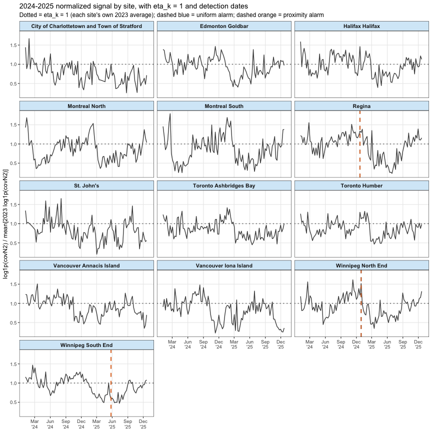

```r
site_names <- rownames(norm_matrix)

alarm_df <- data.frame(
  site       = rep(site_names, 2),
  allowance  = rep(c("uniform", "proximity"), each = K_sites),
  stop_date  = c(results_df$uniform, results_df$proximity)
) %>%
  filter(stop_date != "no alarm") %>%
  mutate(alarm_date = as.Date(stop_date))

norm_test_df <- as.data.frame(t(norm_matrix[, test_idx, drop = FALSE])) %>%
  tibble::rownames_to_column("date_chr") %>%
  tidyr::pivot_longer(-date_chr, names_to = "site", values_to = "norm") %>%
  dplyr::mutate(date = as.Date(date_chr))

p_alarm <- ggplot(norm_test_df, aes(x = date, y = norm)) +
  geom_line(colour = "gray30", linewidth = 0.5, na.rm = TRUE) +
  geom_hline(yintercept = 1, linetype = "dotted", colour = "grey40", linewidth = 0.6) +
  geom_vline(data = filter(alarm_df, allowance == "uniform"),
             aes(xintercept = alarm_date), colour = "#457b9d",
             linetype = "dashed", linewidth = 0.7) +
  geom_vline(data = filter(alarm_df, allowance == "proximity"),
             aes(xintercept = alarm_date), colour = "#e07020",
             linetype = "dashed", linewidth = 0.7) +
  facet_wrap(~ site, ncol = 3) +
  scale_x_date(date_breaks = "3 months", date_labels = "%b\n'%y") +
  labs(x = NULL, y = "log1p(covN2) / mean[2023 log1p(covN2)]",
       title = "2024-2025 normalized signal by site, with eta_k = 1 and detection dates",
       subtitle = "Dotted = eta_k = 1 (each site's own 2023 average); dashed blue = uniform alarm; dashed orange = proximity alarm") +
  theme_bw(base_size = 9) +
  theme(strip.background = element_rect(fill = "#D6EAF8"),
        strip.text       = element_text(face = "bold", size = 8),
        panel.grid.minor = element_blank())

print(p_alarm)
```

Regina and Winnipeg North End (blue and orange dashed lines coincide for both) show a sustained run of weeks above their dotted $\eta_k$ line right before their December 2024 alarms. Winnipeg South End’s own crossings are visibly weaker – consistent with alarming only under the proximity allowance (orange), five months later, once its neighbor’s alarm had already redirected budget toward it.